# **Forecasting Government Expenditure in Ghana Using Autoregressive Integrated Moving Average with Exogenous Variables (ARIMAX)**

Gershon Tetteh Amanor

April 02, 2026

# 1 Chapter One: Introduction

## 1.1 Background of Study

Government expenditure is a critical pillar of Ghana’s development, financing key sectors such as education, healthcare, infrastructure, and social protection that contribute directly to productivity growth, human capital development, and long-term economic performance (World Bank, 2023). In the majority of developing countries, government is seen as an instrument of change, and hence the size of government expenditure reveals the magnitude of government involvement in the economy.

The shift in the role of government — from traditional functions such as provision of security, administration, and law and order, to direct intervention in income-generating activities like capital investment and distributive roles like subsidies and transfers — has significantly expanded the scope of governments in many countries across the globe.

Government expenditure is defined as the total spending by the government on recurrent items and capital projects, primarily funded through budgetary appropriations and often involving significant allocations for personnel costs (Leonard Onyiruba, 2016). In Ghana, government expenditure includes various components such as total public spending on purchase of goods and services, compensation of employees, interest payments, grants to other government units, non-financial assets, and capital expenditure. As defined by the International Monetary Fund (IMF), general government expenditure consists of total expense and the net acquisition of nonfinancial assets (Statista, 2025).

**Ghana’s fiscal exposure** is characterised by its status as a commodity-dependent economy. Changes in world prices of cocoa, gold, and oil directly affect export earnings, tax revenues, and the overall fiscal balance. When commodity prices rise, revenue and spending pressures typically rise; when prices fall, fiscal stress often triggers spending cuts or arrears. Ghana’s public spending has fluctuated significantly due to changes in political priorities, inflationary pressures, and debt servicing obligations — inconsistencies that make it difficult for policymakers to predict expenditure accurately, often resulting in fiscal imbalances and budget deficits.

These trends underscore a critical need for reliable forecasting tools that can help policymakers anticipate future expenditure paths, identify potential fiscal risk, and make informed, data-driven decisions that ensure long-term fiscal sustainability.

Traditional estimation methods have limitations in handling dynamic economic data; hence time-series models such as the **ARIMAX** (Autoregressive Integrated Moving Average with Exogenous Variables) offer a more reliable approach. In many real situations, the assumption that only past values influence future outcomes is too limited because external factors often play a significant role in influencing the direction and behaviour of a time series. This is where ARIMAX becomes particularly valuable — by integrating exogenous variables directly into the forecasting process, allowing for more realistic and accurate predictions.

## 1.2 Problem Statement

Government expenditure in Ghana faces several significant challenges and limitations, primarily driven by high public debt, a narrow revenue base, and weaknesses in public financial management (PFM) systems. Despite fiscal reforms, Ghana continues to face budget overruns, expenditure volatility, and debt-related pressures. The May 2023 IMF Extended Credit Facility (ECF) arrangement was triggered by severe fiscal and debt vulnerabilities following external shocks and policy slippages (Ministry of Finance, Ghana).

Awariefe & Ogumeyo (2023) found that traditional regression (MLR) underperforms when predicting government expenditure because it cannot handle complex, non-linear macro dynamics. Djakou & Jiang (2023) found that an ARIMA(1,1,1) model assumes a linear trend and does not fully capture external macro shocks such as volatility in budget performance. While several studies have applied ARIMA-type models in Ghana for forecasting inflation, GDP, or tax revenue, there is limited evidence of similar applications for **government expenditure forecasting using the ARIMAX framework**.

This methodological gap reduces policymakers’ ability to anticipate the implications of macroeconomic shocks and IMF fiscal regimes. This study addresses the gap by applying ARIMAX with population, revenue, and GDP as exogenous variables to deliver more reliable fiscal forecasts for Ghana.

## 1.3 Objectives of the Study

**General Objective:** To develop an ARIMAX-based forecasting model for Ghana’s government expenditure, using population, government revenue, and GDP as exogenous variables.

**Specific Objectives:**

1. To examine historical trends and volatility in Ghana’s government expenditure (1983–2024).
2. To assess the influence of macroeconomic variables (population, revenue, GDP) on government expenditure.
3. To estimate optimal ARIMAX specifications and generate out-of-sample forecasts.
4. To evaluate whether ARIMAX with exogenous variables improves forecasting accuracy relative to a univariate ARIMA baseline.

## 1.4 Research Questions

1. What are the dominant trends and fluctuations in Ghana’s government expenditure over time?
2. How do population growth, government revenue, and GDP movements affect government expenditure?
3. Does an ARIMAX model with macroeconomic exogenous variables improve forecasting accuracy relative to ARIMA?
4. Which combination of exogenous variables yields the most parsimonious and accurate ARIMAX specification?

## 1.5 Significance of the Study

This study is significant on multiple fronts:

- **Policy relevance:** Improves expenditure forecasts that help the Ministry of Finance and Parliament set realistic budget ceilings, reduce expenditure arrears, and better manage fiscal risks.
- **Methodological contribution:** Demonstrates the effectiveness of parsimonious ARIMAX modelling in a developing, commodity-dependent economy, contributing to the applied time-series econometrics literature.
- **Institutional utility:** Provides a replicable, transparent, and data-driven analytical framework that can be adopted by the Bank of Ghana, the National Development Planning Commission, and development partners for medium-term expenditure planning.

# 2 Chapter Two: Literature Review

## 2.1 Theoretical Foundations

The theoretical framework for this study draws on several interrelated strands of economic and statistical theory:

**Box-Jenkins ARIMA Methodology**  
The theoretical foundation for ARIMA (Autoregressive Integrated Moving Average) modelling is based on the Box-Jenkins methodology developed by George Box and Gwilym Jenkins (1970), which establishes a systematic process for identification, estimation, and diagnostic checking of time series models. ARIMAX extends this framework by incorporating exogenous regressors (transfer functions), allowing the model to capture external influences on the primary series.

**Keynesian Fiscal Theory**  
John Maynard Keynes (1936) posits that government spending is a critical component of aggregate demand and a powerful tool for economic stabilisation. This perspective reinforces the importance of accurately forecasting expenditure to guide effective fiscal planning and ensure macroeconomic stability. According to Keynesian theory, an increase in government expenditure leads to an increase in aggregate demand, production, and ultimately GDP — making GDP a natural exogenous candidate in the ARIMAX framework.

**Wagner’s Law**  
Named after German economist Adolph Wagner, this hypothesis posits that as an economy develops over time, government expenditure grows more than proportionally relative to national income. Wagner’s Law implies a long-run upward drift in public spending as economies grow, providing the theoretical basis for including GDP and population as exogenous drivers of expenditure.

**Peacock-Wiseman Displacement Hypothesis**  
Peacock and Wiseman (1961) argue that public expenditure does not increase at a steady rate, but rather jumps in response to major economic or social disturbances (wars, crises, pandemics). Once elevated, spending rarely returns to its pre-shock level — a “displacement” effect. This theoretical lens is important for understanding Ghana’s expenditure jumps around periods of economic crisis.

**Commodity-Price Fiscal Linkage**  
In commodity-exporting economies, global price shocks influence tax receipts, borrowing costs, and expenditure choices. IMF working paper evidence (Spatafora & Samake, 2012) shows both revenue and expenditure respond significantly to commodity price movements, making fiscal policy highly procyclical in such settings.

## 2.2 Empirical Literature

A growing body of literature confirms that ARIMAX models consistently outperform baseline ARIMA models when relevant exogenous information is available:

- **Jiayi Yang (2025):** Applied ARIMA, ARIMAX, VAR, and GLM to forecast China’s university admission rates (1977–2024). The ARIMAX model, incorporating GDP and newborn population as exogenous variables, produced the lowest forecast errors and provided deeper insights into how macroeconomic factors drive admission rates.
- **Fairuz Azizah et al. (2025):** Modelled Indonesia’s Human Development Index using ARIMAX with inflation and infant mortality as exogenous variables. Results confirmed that including these external drivers significantly improved estimation accuracy over the pure ARIMA specification.
- **Coker (2025):** Compared ARIMA, ARIMAX, and VAR for short-term inflation forecasting in Sierra Leone. The ARIMAX model incorporating the exchange rate as an exogenous variable significantly outperformed the alternatives, underscoring the importance of external drivers in small, open economies.
- **Abdulazeez (2021):** Demonstrated in a Nigeria GDP forecasting study that ARIMAX with agriculture, industry, and services sector shares consistently outperformed ARIMA across all error metrics (RMSE: 899 vs 1,662; MSE: 568 vs 1,161).
- **Ajibode & Adeboye:** Applied ARIMA and ARIMAX to COVID-19 mortality modelling in Nigeria. ARIMAX with confirmed cases as an exogenous variable produced the lowest MAE (5.98) and RMSE (8.54), outperforming the pure ARIMA specification.
- **Michael Safo Ofori et al.:** Forecasting VAT revenue in Ghana using ARIMA with intervention, demonstrating the utility of time-series methods for Ghanaian fiscal data and validating the approach adopted in the present study.
- **Boachie et al. (2022):** Examined Ghana’s public health spending (1980–2014) using 3SLS estimators, finding that IMF programme conditionalities slightly constrained public health spending, supporting the inclusion of IMF regime indicators in fiscal forecasting models.

## 2.3 Chapter Summary

The reviewed literature consistently highlights that: (1) ARIMA models are a well-established baseline for univariate fiscal forecasting; (2) the incorporation of exogenous variables through the ARIMAX framework reliably improves forecasting accuracy; (3) macro-fiscal variables such as GDP, revenue, and population are the most empirically validated exogenous drivers; and (4) there is a notable gap in the application of ARIMAX to Ghana’s government expenditure forecasting — the gap this study addresses.

# 3 Chapter Three: Methodology

## 3.2 Data Sources and Variables

Table 1: Variable Description and Sources

| Variable | Description | Unit | Source |
| --- | --- | --- | --- |
| GE (Y) | Total Government Expenditure (Net Lending) | Million GHS → log(USD) | Bank of Ghana — Gov. Fiscal Operations |
| POPULATION (X1) | Ghana’s Annual Population | Persons | World Bank / Ghana Statistical Service |
| REVENUE (X2) | Total Government Revenue (Million GHS → USD) | log(USD) | Bank of Ghana — Gov. Fiscal Operations |
| GDP (X3) | Nominal GDP (USD Billion → USD) | log(USD) | World Bank National Accounts |

The dataset spans **1983 to 2024**, with the following coverage:

- **Government Expenditure:** Annual total expenditure and net lending (millions of Ghana Cedis), sourced from the Bank of Ghana’s Government Fiscal Operations report.
- **Population:** Annual population figures used as a demographic driver of public expenditure demand.
- **Revenue:** Annual government revenue (millions of Ghana Cedis), converted to USD and log-transformed.
- **GDP:** Nominal GDP in USD billions, converted to USD and log-transformed.

All currency-denominated variables (expenditure, revenue) are **converted from Ghana Cedis to US Dollars** using the contemporaneous annual average exchange rate. This conversion normalises the data against the extreme nominal exchange-rate depreciation that Ghana experienced over the study period, particularly post-2014. **Log transformations** are then applied to all monetary variables to stabilise variance and linearise exponential growth trends.

## 3.3 Analytical Framework: The ARIMAX Model

### 3.3.1 ARIMA Components

The ARIMA(p, d, q) model combines three core components:

- **AR(p) — Autoregressive component:** Models the relationship between the current observation and $p$ lagged values:
  $$X_t = c + \phi_1 X_{t-1} + \phi_2 X_{t-2} +
  \ldots + \phi_p X_{t-p} + \epsilon_t$$
- **I(d) — Integration (Differencing):** The series is differenced $d$ times to achieve stationarity, removing trend and unit-root behaviour.
- **MA(q) — Moving Average component:** Models the relationship between the current value and $q$ lagged forecast errors:
  $$X_t = c + \epsilon_t + \theta_1 \epsilon_{t-1} +
  \theta_2 \epsilon_{t-2} + \ldots + \theta_q
  \epsilon_{t-q}$$

Combined:
$$X_t = c + \sum_{i=1}^{p}\phi_i
X_{t-i} + \sum_{j=1}^{q}\theta_j \epsilon_{t-j} +
\epsilon_t$$

### 3.3.2 ARIMAX Extension

The ARIMAX model augments the ARIMA framework with exogenous regressors $X_k$:

$$Y_t = \mu + \sum_{i=1}^{p}\phi_i Y_{t-i}
+ \sum_{j=1}^{q}\theta_j \epsilon_{t-j} + \sum_{k}\beta_k X_{k,t} +
\epsilon_t$$

where: - $Y_t$ = Government Expenditure (log USD) at time $t$ - $X_{k,t}$ = exogenous variables (population, log revenue, log GDP) - $\beta_k$ = coefficients for the exogenous variables - $\epsilon_t \sim WN(0, \sigma^2)$

### 3.3.3 Model Selection Criteria

| Criterion | Formula | Preference |
| --- | --- | --- |
| AIC | $-2\log(L) + 2k$ | Lower is better |
| BIC | $-2\log(L) + k\log(n)$ | Lower is better |
| RMSE | $\sqrt{\frac{1}{n}\sum e_t^2}$ | Lower is better |
| MAE | $\frac{1}{n}\sum\|e_t\|$ | Lower is better |
| MAPE | $\frac{100}{n}\sum\|e_t/Y_t\|$ | Lower is better |
| MASE | Scaled by naïve forecast MAE | < 1 is better |

### 3.3.4 Stationarity Tests

**Augmented Dickey-Fuller (ADF) Test:**
$$\Delta y_t = \alpha + \beta t + \rho y_{t-1} +
\sum_{i=1}^{k}\phi_i \Delta y_{t-i} + \epsilon_t$$

- $H_0$: Unit root present (non-stationary)
- $H_1$: Series is stationary
- Reject $H_0$ if p-value < 0.05

# 4 Chapter Four: Data Analysis and Results

## 4.1 Setup — Libraries and Global Options

All required R packages are loaded here. These cover time series modelling (`forecast`, `tseries`), multicollinearity diagnostics (`car`), data import (`readxl`), and data manipulation/visualisation (`tidyverse`).

```r
# Time series modelling and forecasting toolkit
library(forecast)

# Augmented Dickey-Fuller and KPSS unit root tests
library(tseries)

# Variance Inflation Factor for multicollinearity diagnostics
library(car)

# Reading Excel data files
library(readxl)

# Data manipulation and visualisation (dplyr, ggplot2, tidyr)
library(tidyverse)
```

## 4.2 Data Loading and Preprocessing

### 4.2.1 Loading the Dataset

```r
# Load the annual fiscal dataset (1983–2024)
data_raw <- read_excel("Data2.xlsx")

# Preview the raw data structure
glimpse(data_raw)
```

```
#> Rows: 42
#> Columns: 7
#> $ YEAR                        <dbl> 1983, 1984, 1985, 1986, 1987, 1988, 1989, …
#> $ EXPENDITURE                 <dbl> 1.51, 2.75, 4.79, 7.33, 10.69, 14.99, 20.4…
#> $ POPULATION                  <dbl> 13029836, 13370590, 13661229, 13965217, 14…
#> $ ELECTION                    <dbl> 0, 0, 0, 0, 0, 0, 0, 0, 0, 1, 0, 0, 0, 1, …
#> $ `GDP USD BILLION`           <dbl> 4.06, 4.41, 4.50, 5.74, 5.07, 5.20, 5.25, …
#> $ `REVENUE MILLION OF  CEDIS` <dbl> 1.03, 2.26, 4.03, 7.36, 11.10, 15.38, 21.4…
#> $ EXCHANGE_RATE               <dbl> 0.00, 0.01, 0.01, 0.01, 0.02, 0.02, 0.03, …
```

### 4.2.2 Currency Conversion and Log Transformation

Log transformations are applied to all monetary variables to: 1. Stabilise the exponential growth in variance (heteroscedasticity correction) 2. Linearise the long-run upward trend, making the series more amenable to ARIMA modelling 3. Enable percentage-change interpretation of first differences

```r
data <- data_raw |>
  mutate(
    # Convert GHS expenditure (millions) to USD
    GOV_EXP_DOLLARS = EXPENDITURE * 1000000 / EXCHANGE_RATE,

    # Convert GHS revenue (millions) to USD
    REVEVENUE = `REVENUE MILLION OF  CEDIS` * 1000000 / EXCHANGE_RATE,

    # Convert GDP (USD billions) to USD for unit consistency
    GDP = `GDP USD BILLION` * 1000000000,

    # Apply natural log transformation to all monetary variables
    # Rationale: log stabilises exponential variance growth and linearises trend
    LOG_EXPENDITURE = log(GOV_EXP_DOLLARS),
    LOG_REVENUE     = log(REVEVENUE),
    LOG_GDP         = log(GDP)
  ) |>
  # Remove original pre-transformation columns and the election dummy
  # (election effects are not part of this specification)
  select(-c(EXPENDITURE, `REVENUE MILLION OF  CEDIS`, `GDP USD BILLION`,
            EXCHANGE_RATE, ELECTION)) |>
  # Remove rows where division by zero produced Inf values
  filter(GOV_EXP_DOLLARS != Inf)

# Show the processed dataset structure
glimpse(data)
```

```
#> Rows: 38
#> Columns: 8
#> $ YEAR            <dbl> 1984, 1985, 1986, 1987, 1988, 1989, 1990, 1991, 1992, …
#> $ POPULATION      <dbl> 13370590, 13661229, 13965217, 14289108, 14636568, 1500…
#> $ GOV_EXP_DOLLARS <dbl> 275000000, 479000000, 733000000, 534500000, 749500000,…
#> $ REVEVENUE       <dbl> 226000000, 403000000, 736000000, 555000000, 769000000,…
#> $ GDP             <dbl> 4410000000, 4500000000, 5740000000, 5070000000, 520000…
#> $ LOG_EXPENDITURE <dbl> 19.43228, 19.98721, 20.41266, 20.09684, 20.43492, 20.3…
#> $ LOG_REVENUE     <dbl> 19.23605, 19.81445, 20.41674, 20.13448, 20.46060, 20.3…
#> $ LOG_GDP         <dbl> 22.20714, 22.22734, 22.47073, 22.34661, 22.37192, 22.3…
```

### 4.2.3 Processed Data Summary

```r
summary(data[, c("GOV_EXP_DOLLARS", "LOG_EXPENDITURE",
                 "LOG_REVENUE", "LOG_GDP", "POPULATION")])
```

```
#>  GOV_EXP_DOLLARS       LOG_EXPENDITURE  LOG_REVENUE       LOG_GDP
#>  Min.   :  275000000   Min.   :19.43   Min.   :19.24   Min.   :22.21
#>  1st Qu.: 1298788194   1st Qu.:20.98   1st Qu.:20.71   1st Qu.:22.50
#>  Median : 2043748876   Median :21.44   Median :21.24   Median :22.76
#>  Mean   : 5373578988   Mean   :21.79   Mean   :21.60   Mean   :23.38
#>  3rd Qu.: 9750098001   3rd Qu.:23.00   3rd Qu.:22.86   3rd Qu.:24.43
#>  Max.   :18808242685   Max.   :23.66   Max.   :23.21   Max.   :25.10
#>    POPULATION
#>  Min.   :13370590
#>  1st Qu.:16690437
#>  Median :21013046
#>  Mean   :21768557
#>  3rd Qu.:26574473
#>  Max.   :32518665
```

### 4.2.4 Defining Time Series Objects

```r
# Dependent variable: log government expenditure as annual time series
# Starting from 1984 (first year with valid exchange rate data)
Y <- ts(data$LOG_EXPENDITURE, start = 1984, frequency = 1)

# Exogenous variable matrix used in ARIMAX models
xreg_vars <- data[, c("POPULATION", "LOG_REVENUE", "LOG_GDP")]

# Forecast horizon: 10 years beyond the end of the estimation sample
h_period <- 10

cat("Dependent variable (Y): Log Government Expenditure\n")
```

```
#> Dependent variable (Y): Log Government Expenditure
```

```r
cat("Sample period:", start(Y)[1], "to", end(Y)[1], "\n")
```

```
#> Sample period: 1984 to 2021
```

```r
cat("Observations:", length(Y), "\n")
```

```
#> Observations: 38
```

```r
cat("Forecast horizon:", h_period, "years\n")
```

```
#> Forecast horizon: 10 years
```

## 4.3 Descriptive Analysis and Trend Exploration

### 4.3.1 Historical Trend of Government Expenditure

Before formal modelling, it is important to visually inspect Ghana’s government expenditure history. The time series plot below reveals the character of the data: the direction of the trend, any structural breaks, and the general growth trajectory.

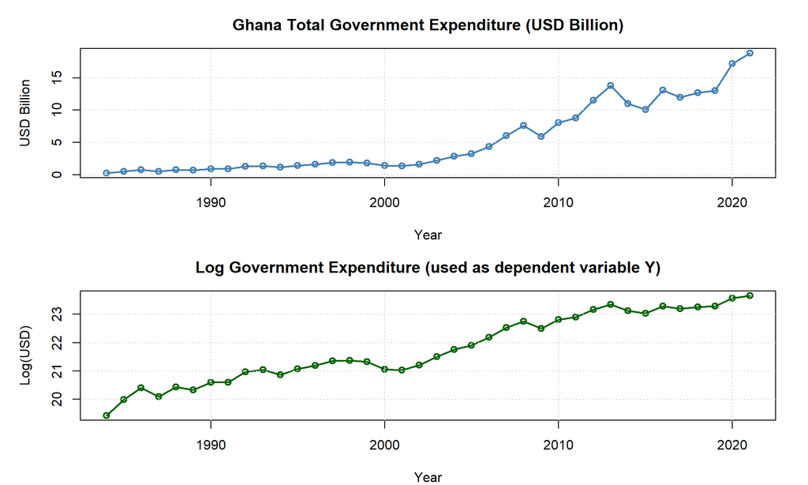

```r
par(mfrow = c(2, 1), mar = c(4, 5, 3, 2))

# Plot 1: Raw USD expenditure
plot(ts(data$GOV_EXP_DOLLARS / 1e9, start = 1984),
     type = "o", col = "steelblue", lwd = 2,
     main = "Ghana Total Government Expenditure (USD Billion)",
     ylab = "USD Billion", xlab = "Year")
grid(col = "lightgray", lty = "dotted")

# Plot 2: Log-transformed expenditure (used as Y in models)
plot(Y,
     type = "o", col = "darkgreen", lwd = 2,
     main = "Log Government Expenditure (used as dependent variable Y)",
     ylab = "Log(USD)", xlab = "Year")
grid(col = "lightgray", lty = "dotted")
```

> **Observation:** The raw expenditure series exhibits exponential growth — characteristic of a nominal fiscal variable in a developing economy undergoing both real growth and significant price-level increases. The log transformation converts this to a near-linear upward trend, more appropriate for ARIMA-based modelling. Notable inflections (post-2014 cedi depreciation, post-2020 COVID-19 fiscal expansion) are visible in both plots.

### 4.3.2 Exogenous Variables Over Time

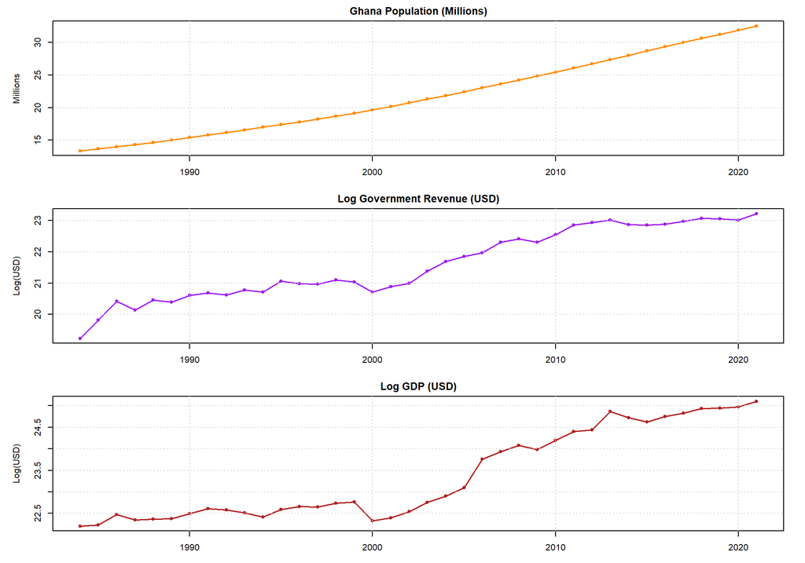

```r
par(mfrow = c(3, 1), mar = c(3, 5, 2, 2))

plot(ts(data$POPULATION / 1e6, start = 1984),
     type = "o", col = "darkorange", lwd = 1.5,
     main = "Ghana Population (Millions)", ylab = "Millions", xlab = "")
grid(col = "lightgray", lty = "dotted")

plot(ts(data$LOG_REVENUE, start = 1984),
     type = "o", col = "purple", lwd = 1.5,
     main = "Log Government Revenue (USD)", ylab = "Log(USD)", xlab = "")
grid(col = "lightgray", lty = "dotted")

plot(ts(data$LOG_GDP, start = 1984),
     type = "o", col = "firebrick", lwd = 1.5,
     main = "Log GDP (USD)", ylab = "Log(USD)", xlab = "Year")
grid(col = "lightgray", lty = "dotted")
```

> **Observation:** All three exogenous variables exhibit persistent upward trends over the sample period. Population growth is smooth and demographic in nature. Revenue and GDP share a similar trajectory to expenditure, reflecting the co-movement between fiscal variables and macroeconomic performance over Ghana’s development path. This co-movement is precisely the signal that ARIMAX is designed to exploit.

## 4.4 Multicollinearity Check (VIF)

Before including multiple exogenous regressors in the ARIMAX model, potential **multicollinearity** is assessed using the **Variance Inflation Factor (VIF)**. Multicollinearity arises when two or more predictors are highly linearly correlated, inflating coefficient standard errors and undermining interpretability.

**Decision rule:** - VIF < 5 → Acceptable - VIF 5–10 → Moderate concern; monitor - VIF > 10 → Severe multicollinearity → consider dimensionality reduction or variable exclusion

```r
# Fit auxiliary OLS regression solely to compute VIF values
# (Not used for forecasting; diagnostic purpose only)
vif_model <- lm(Y ~ POPULATION + LOG_REVENUE + LOG_GDP, data = data)

cat("=== Variance Inflation Factors (VIF) ===\n")
```

```
#> === Variance Inflation Factors (VIF) ===
```

```r
print(vif(vif_model))
```

```
#>  POPULATION LOG_REVENUE     LOG_GDP
#>    17.69051    20.10369    15.43043
```

```r
cat("\nNote: VIF > 10 indicates severe multicollinearity.\n")
```

```
#>
#> Note: VIF > 10 indicates severe multicollinearity.
```

```r
cat("VIF > 5 suggests moderate collinearity that may inflate standard errors.\n")
```

```
#> VIF > 5 suggests moderate collinearity that may inflate standard errors.
```

## 4.5 4.5 Stationarity Testing and Order of Integration

### 4.5.1 ADF Test on the Level Series

The ADF test evaluates whether the log expenditure series $Y_t$ contains a unit root (is non-stationary):

- **H₀:** Unit root present → series is non-stationary
- **H₁:** No unit root → series is stationary
- **Reject H₀** if p-value < 0.05

```r
cat("=== ADF Test: Log Government Expenditure (Level) ===\n")
```

```
#> === ADF Test: Log Government Expenditure (Level) ===
```

```r
adf_level <- adf.test(Y)
print(adf_level)
```

```
#>
#>  Augmented Dickey-Fuller Test
#>
#> data:  Y
#> Dickey-Fuller = -2.2832, Lag order = 3, p-value = 0.4626
#> alternative hypothesis: stationary
```

```r
if (adf_level$p.value > 0.05) {
  cat("\n>> Decision: Fail to reject H0 (p =", round(adf_level$p.value, 4),
      ") — Series is NON-STATIONARY. Differencing required.\n")
} else {
  cat("\n>> Decision: Reject H0 (p =", round(adf_level$p.value, 4),
      ") — Series is STATIONARY. No differencing needed.\n")
}
```

```
#>
#> >> Decision: Fail to reject H0 (p = 0.4626 ) — Series is NON-STATIONARY. Differencing required.
```

### 4.5.2 Second-Order Differencing

If the level series is non-stationary, differencing is applied to remove the trend and induce stationarity. Second-order differencing (d = 2) corresponds to the integration order I(2), which is common for fiscal series with strong exponential growth.

```r
# Apply second-order differencing
log_y_diff <- diff(Y, differences = 2)

cat("=== ADF Test: Second-Order Differenced Series ===\n")
```

```
#> === ADF Test: Second-Order Differenced Series ===
```

```r
adf_diff <- adf.test(log_y_diff)
print(adf_diff)
```

```
#>
#>  Augmented Dickey-Fuller Test
#>
#> data:  log_y_diff
#> Dickey-Fuller = -4.8497, Lag order = 3, p-value = 0.01
#> alternative hypothesis: stationary
```

```r
if (adf_diff$p.value < 0.05) {
  cat("\n>> Decision: Reject H0 (p =", round(adf_diff$p.value, 4),
      ") — Differenced series is STATIONARY. d = 2 is appropriate.\n")
} else {
  cat("\n>> Decision: Fail to reject H0 — further differencing may be required.\n")
}
```

```
#>
#> >> Decision: Reject H0 (p = 0.01 ) — Differenced series is STATIONARY. d = 2 is appropriate.
```

### 4.5.3 Visual Comparison: Level vs Differenced Series

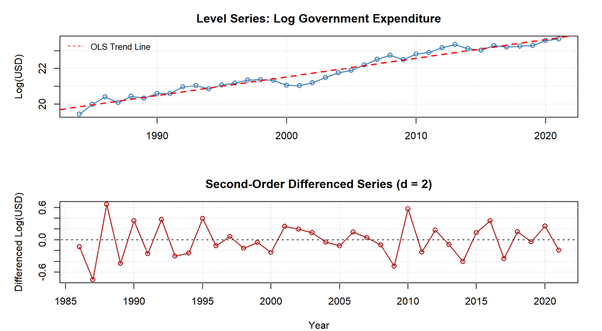

Figure 3: Level and Second-Differenced Log Government Expenditure

```r
par(mfrow = c(2, 1), mar = c(4, 5, 3, 2))

plot(Y, type = "o", col = "steelblue", lwd = 1.5,
     main = "Level Series: Log Government Expenditure",
     ylab = "Log(USD)", xlab = "")
abline(lm(Y ~ time(Y)), col = "red", lty = 2, lwd = 2)
legend("topleft", legend = "OLS Trend Line", col = "red",
       lty = 2, bty = "n", cex = 0.85)
grid(col = "lightgray", lty = "dotted")

plot(log_y_diff, type = "o", col = "firebrick", lwd = 1.5,
     main = "Second-Order Differenced Series (d = 2)",
     ylab = "Differenced Log(USD)", xlab = "Year")
abline(h = 0, col = "black", lty = 2)
grid(col = "lightgray", lty = "dotted")
```

## 4.6 ACF and PACF Analysis — Identifying Model Orders

The **Autocorrelation Function (ACF)** and **Partial Autocorrelation Function (PACF)** are the primary tools for identifying the autoregressive order (p) and moving average order (q) in the Box-Jenkins framework:

| Pattern | Implication |
| --- | --- |
| PACF: spike at lag $k$, then cuts off | AR($k$) component |
| ACF: spike at lag $k$, then cuts off | MA($k$) component |
| Both decay slowly | Mixed ARMA; use `auto.arima` |
| No significant spikes in differenced series | Differencing sufficient; d is appropriate |

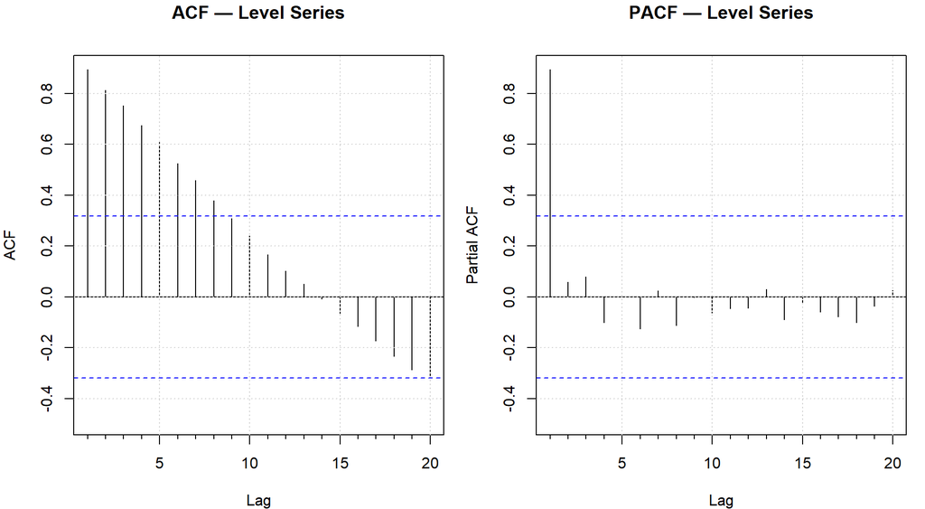

Figure 4: ACF and PACF of Level Series (Log Government Expenditure)

```r
par(mfrow = c(1, 2), mar = c(4, 4, 3, 1))
Acf(Y,  main = "ACF — Level Series",  lag.max = 20); grid()
Pacf(Y, main = "PACF — Level Series", lag.max = 20); grid()
```

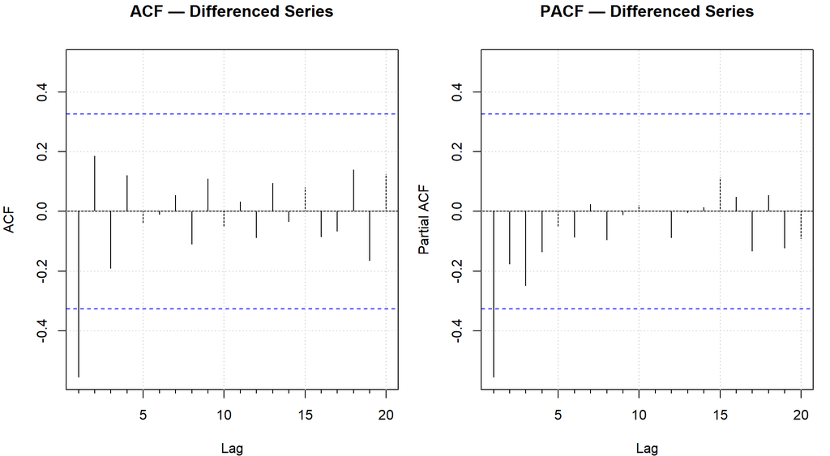

Figure 5: ACF and PACF of Second-Differenced Series

```r
par(mfrow = c(1, 2), mar = c(4, 4, 3, 1))
Acf(log_y_diff,  main = "ACF — Differenced Series",  lag.max = 20); grid()
Pacf(log_y_diff, main = "PACF — Differenced Series", lag.max = 20); grid()
```

> **Interpretation:** The level series ACF decays slowly (consistent with non-stationarity). In the differenced series, spikes that fall within the 95% confidence bands (blue dashed lines at ±1.96/√n) suggest that differencing has removed most autocorrelation. Remaining significant spikes, if any, guide the selection of p and q. `auto.arima()` in subsequent sections performs a systematic AIC/BIC-guided search to confirm the optimal orders.

## 4.7 Defining Forecast Variables

Future values of the exogenous variables must be specified to generate ARIMAX out-of-sample forecasts. A **mean-projection approach** is used here, setting each exogenous variable to its in-sample mean across the 10-year horizon. This is a conservative, assumption-neutral approach.

> In practice, scenario-based projections (e.g., IMF WEO GDP projections, UN population forecasts) would be preferred for policy applications. The mean projection provides a baseline forecast that captures the average historical influence of each exogenous variable.

```r
# Mean-based projection of exogenous variables over 10-year horizon
future_population <- rep(mean(data$POPULATION), h_period)
future_revenue    <- rep(mean(data$LOG_REVENUE), h_period)
future_gdp        <- rep(mean(data$LOG_GDP),     h_period)

# Assemble as a matrix with column names matching the estimation xreg
future_xreg <- cbind(future_population, future_revenue, future_gdp)
colnames(future_xreg) <- colnames(xreg_vars)

cat("Future exogenous variable projections (mean of in-sample values):\n")
```

```
#> Future exogenous variable projections (mean of in-sample values):
```

```r
cat("Population (mean):", round(mean(data$POPULATION), 0), "\n")
```

```
#> Population (mean): 21768557
```

```r
cat("Log Revenue (mean):", round(mean(data$LOG_REVENUE), 4), "\n")
```

```
#> Log Revenue (mean): 21.5995
```

```r
cat("Log GDP (mean):", round(mean(data$LOG_GDP), 4), "\n")
```

```
#> Log GDP (mean): 23.3838
```

## 4.8 Model 1: ARIMA Baseline

The univariate ARIMA model serves as the benchmark against which all ARIMAX specifications are evaluated. It explains Ghana’s log expenditure solely from its own historical dynamics — past values and lagged shocks — with no external information.

### 4.8.1 Model Estimation

`auto.arima()` with `stepwise = FALSE` and `approximation = FALSE` performs an exhaustive search across candidate (p, d, q) combinations, selecting the specification with the lowest AIC. Maximum Likelihood Estimation (MLE) is used for parameter estimation, providing efficient and asymptotically unbiased estimates.

```r
cat("=== Fitting ARIMA Baseline Model ===\n")
```

```
#> === Fitting ARIMA Baseline Model ===
```

```r
cat("Method: Maximum Likelihood Estimation (MLE)\n")
```

```
#> Method: Maximum Likelihood Estimation (MLE)
```

```r
cat("Selection: AIC-minimising exhaustive search\n\n")
```

```
#> Selection: AIC-minimising exhaustive search
```

```r
arima_fit <- auto.arima(
  Y,
  stepwise      = FALSE,   # Exhaustive, not stepwise, search
  approximation = FALSE,   # Exact (not approximate) AIC values
  method        = "ML"     # Maximum Likelihood Estimation
)

summary(arima_fit)
```

```
#> Series: Y
#> ARIMA(0,1,0) with drift
#>
#> Coefficients:
#>        drift
#>       0.1142
#> s.e.  0.0340
#>
#> sigma^2 = 0.0441:  log likelihood = 5.76
#> AIC=-7.51   AICc=-7.16   BIC=-4.29
#>
#> Training set error measures:
#>                        ME      RMSE      MAE         MPE      MAPE      MASE
#> Training set 0.0005083704 0.2043941 0.168418 0.004295336 0.7818951 0.8428475
#>                     ACF1
#> Training set -0.09354056
```

### 4.8.2 Residual Diagnostics

A valid ARIMA model should produce **white noise residuals** — residuals that are uncorrelated, approximately normally distributed, and have constant variance. Any remaining structure in the residuals indicates model misspecification.

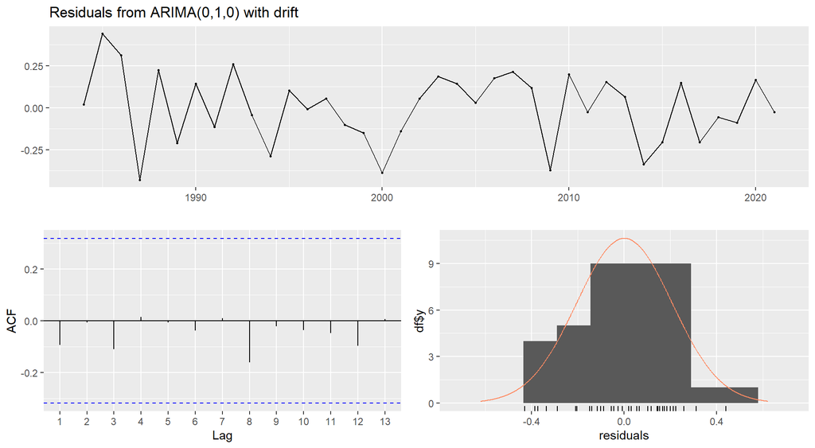

Figure 6: ARIMA Baseline — Residual Diagnostics

```
#>
#>  Ljung-Box test
#>
#> data:  Residuals from ARIMA(0,1,0) with drift
#> Q* = 2.2888, df = 8, p-value = 0.9709
#>
#> Model df: 0.   Total lags used: 8
```

```r
checkresiduals(arima_fit)
```

### 4.8.3 Ljung-Box Test for Residual Autocorrelation

The Ljung-Box test formally tests whether the first 10 residual autocorrelations are jointly zero:

- **H₀:** Residuals are uncorrelated (white noise) — model is adequate
- **H₁:** Significant autocorrelation remains — model may be misspecified
- **Rule:** p-value > 0.05 → fail to reject H₀ → residuals are clean

```r
lb_arima <- Box.test(residuals(arima_fit), lag = 10, type = "Ljung-Box")
cat("=== Ljung-Box Test (lag = 10) — ARIMA Baseline ===\n")
```

```
#> === Ljung-Box Test (lag = 10) — ARIMA Baseline ===
```

```r
print(lb_arima)
```

```
#>
#>  Box-Ljung test
#>
#> data:  residuals(arima_fit)
#> X-squared = 2.3896, df = 10, p-value = 0.9924
```

```r
if (lb_arima$p.value > 0.05) {
  cat("\n>> Decision: p =", round(lb_arima$p.value, 4),
      "> 0.05 — Fail to reject H0. Residuals are white noise. Model is adequate.\n")
} else {
  cat("\n>> Decision: p =", round(lb_arima$p.value, 4),
      "< 0.05 — Reject H0. Residual autocorrelation detected. Model may be misspecified.\n")
}
```

```
#>
#> >> Decision: p = 0.9924 > 0.05 — Fail to reject H0. Residuals are white noise. Model is adequate.
```

### 4.8.4 Information Criteria and Accuracy

```r
cat("=== ARIMA — Model Fit Statistics ===\n")
```

```
#> === ARIMA — Model Fit Statistics ===
```

```r
cat("AIC:", round(AIC(arima_fit), 4), "\n")
```

```
#> AIC: -7.5107
```

```r
cat("BIC:", round(BIC(arima_fit), 4), "\n\n")
```

```
#> BIC: -4.2889
```

```r
cat("=== ARIMA — In-Sample Accuracy Metrics ===\n")
```

```
#> === ARIMA — In-Sample Accuracy Metrics ===
```

```r
print(accuracy(arima_fit))
```

```
#>                        ME      RMSE      MAE         MPE      MAPE      MASE
#> Training set 0.0005083704 0.2043941 0.168418 0.004295336 0.7818951 0.8428475
#>                     ACF1
#> Training set -0.09354056
```

### 4.8.5 ARIMA Forecast (10-Year Horizon)

```r
arima_forecast <- forecast(arima_fit, h = h_period)

cat("=== ARIMA — Point Forecasts and Prediction Intervals ===\n")
```

```
#> === ARIMA — Point Forecasts and Prediction Intervals ===
```

```r
print(arima_forecast)
```

```
#>      Point Forecast    Lo 80    Hi 80    Lo 95    Hi 95
#> 2022       23.77176 23.50264 24.04088 23.36018 24.18334
#> 2023       23.88595 23.50536 24.26655 23.30389 24.46802
#> 2024       24.00015 23.53402 24.46628 23.28727 24.71303
#> 2025       24.11435 23.57611 24.65259 23.29118 24.93751
#> 2026       24.22854 23.62678 24.83031 23.30822 25.14887
#> 2027       24.34274 23.68354 25.00195 23.33457 25.35091
#> 2028       24.45694 23.74492 25.16896 23.36799 25.54588
#> 2029       24.57113 23.80995 25.33232 23.40700 25.73527
#> 2030       24.68533 23.87797 25.49269 23.45058 25.92008
#> 2031       24.79953 23.94850 25.65056 23.49799 26.10107
```

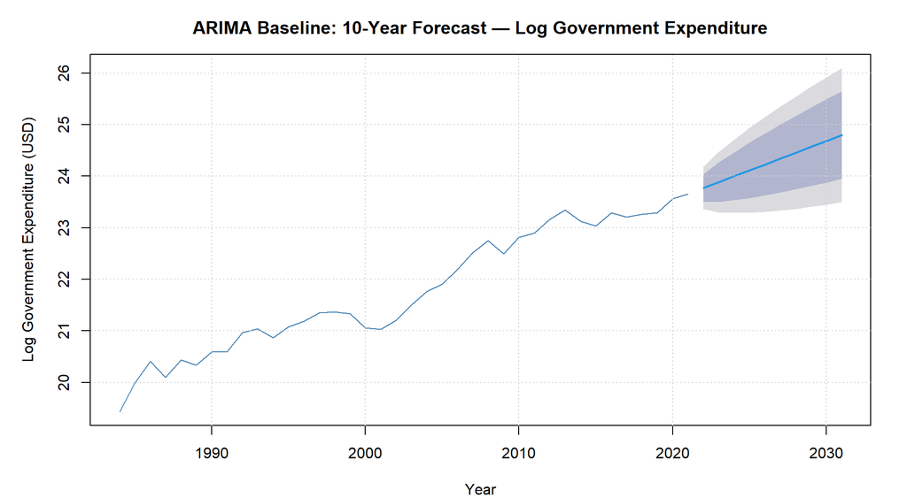

Figure 7: ARIMA — 10-Year Forecast of Log Government Expenditure

```r
par(mfrow = c(1, 1), mar = c(4, 5, 3, 2))
plot(arima_forecast,
     main = "ARIMA Baseline: 10-Year Forecast — Log Government Expenditure",
     ylab = "Log Government Expenditure (USD)",
     xlab = "Year",
     col  = "steelblue")
grid(col = "lightgray", lty = "dotted")
```

## 4.9 Model 2: ARIMAX — All Exogenous Variables

This ARIMAX model includes all three exogenous variables simultaneously: population, log revenue, and log GDP. It tests whether the combined macroeconomic signal from these variables improves on the univariate ARIMA baseline.

```r
cat("=== Fitting ARIMAX — All Exogenous Variables ===\n")
```

```
#> === Fitting ARIMAX — All Exogenous Variables ===
```

```r
cat("Exogenous variables: POPULATION + LOG_REVENUE + LOG_GDP\n\n")
```

```
#> Exogenous variables: POPULATION + LOG_REVENUE + LOG_GDP
```

```r
arimax_fit <- auto.arima(
  Y,
  xreg          = as.matrix(xreg_vars),
  stepwise      = FALSE,
  approximation = FALSE,
  method        = "ML"
)

summary(arimax_fit)
```

```
#> Series: Y
#> Regression with ARIMA(0,0,0) errors
#>
#> Coefficients:
#>       intercept  POPULATION  LOG_REVENUE  LOG_GDP
#>          2.2976      0.0000       0.8356   0.0247
#> s.e.     1.3758      0.0002       0.0758   0.0712
#>
#> sigma^2 = 0.01478:  log likelihood = 28.26
#> AIC=-46.53   AICc=-44.65   BIC=-38.34
#>
#> Training set error measures:
#>                                    ME      RMSE        MAE          MPE
#> Training set -0.000000000000000934926 0.1150152 0.09975323 -0.003032057
#>                   MAPE      MASE      ACF1
#> Training set 0.4592601 0.4992147 0.2935644
```

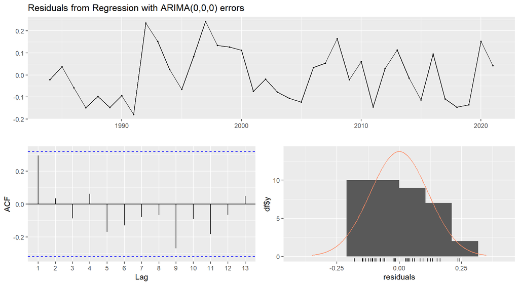

Figure 8: ARIMAX (All Variables) — Residual Diagnostics

```
#>
#>  Ljung-Box test
#>
#> data:  Residuals from Regression with ARIMA(0,0,0) errors
#> Q* = 6.7298, df = 8, p-value = 0.566
#>
#> Model df: 0.   Total lags used: 8
```

```r
checkresiduals(arimax_fit)
```

```r
lb_all <- Box.test(residuals(arimax_fit), lag = 10, type = "Ljung-Box")
cat("=== Ljung-Box Test — ARIMAX (All Variables) ===\n")
```

```
#> === Ljung-Box Test — ARIMAX (All Variables) ===
```

```r
print(lb_all)
```

```
#>
#>  Box-Ljung test
#>
#> data:  residuals(arimax_fit)
#> X-squared = 10.955, df = 10, p-value = 0.3611
```

```r
cat("\n>> Decision: p =", round(lb_all$p.value, 4), "—",
    ifelse(lb_all$p.value > 0.05,
           "Fail to reject H0. Residuals are white noise.",
           "Reject H0. Residual autocorrelation present."), "\n")
```

```
#>
#> >> Decision: p = 0.3611 — Fail to reject H0. Residuals are white noise.
```

```r
cat("=== ARIMAX (All Variables) — Fit Statistics ===\n")
```

```
#> === ARIMAX (All Variables) — Fit Statistics ===
```

```r
cat("AIC:", round(AIC(arimax_fit), 4), "\n")
```

```
#> AIC: -46.5252
```

```r
cat("BIC:", round(BIC(arimax_fit), 4), "\n\n")
```

```
#> BIC: -38.3372
```

```r
cat("=== ARIMAX (All Variables) — Accuracy Metrics ===\n")
```

```
#> === ARIMAX (All Variables) — Accuracy Metrics ===
```

```r
print(accuracy(arimax_fit))
```

```
#>                                    ME      RMSE        MAE          MPE
#> Training set -0.000000000000000934926 0.1150152 0.09975323 -0.003032057
#>                   MAPE      MASE      ACF1
#> Training set 0.4592601 0.4992147 0.2935644
```

```r
arimax_all_forecast <- forecast(arimax_fit, xreg = future_xreg, h = h_period)

cat("=== ARIMAX (All Variables) — Point Forecasts ===\n")
```

```
#> === ARIMAX (All Variables) — Point Forecasts ===
```

```r
print(arimax_all_forecast)
```

```
#>      Point Forecast    Lo 80    Hi 80    Lo 95    Hi 95
#> 2022       21.79411 21.63828 21.94994 21.55579 22.03243
#> 2023       21.79411 21.63828 21.94994 21.55579 22.03243
#> 2024       21.79411 21.63828 21.94994 21.55579 22.03243
#> 2025       21.79411 21.63828 21.94994 21.55579 22.03243
#> 2026       21.79411 21.63828 21.94994 21.55579 22.03243
#> 2027       21.79411 21.63828 21.94994 21.55579 22.03243
#> 2028       21.79411 21.63828 21.94994 21.55579 22.03243
#> 2029       21.79411 21.63828 21.94994 21.55579 22.03243
#> 2030       21.79411 21.63828 21.94994 21.55579 22.03243
#> 2031       21.79411 21.63828 21.94994 21.55579 22.03243
```

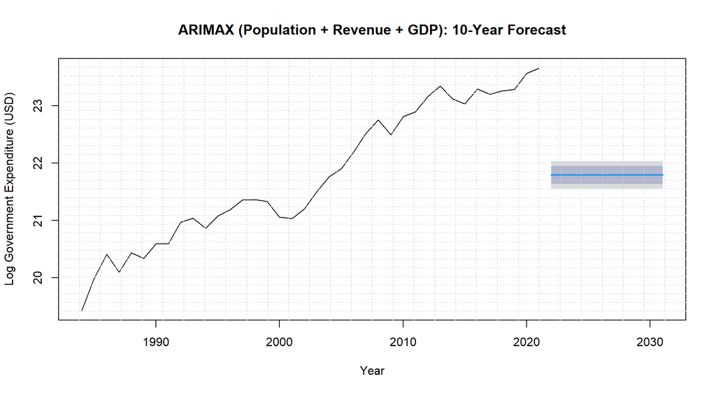

Figure 9: ARIMAX (All Variables) — 10-Year Forecast

```r
par(mfrow = c(1, 1))
plot(arimax_all_forecast,
     main = "ARIMAX (Population + Revenue + GDP): 10-Year Forecast",
     ylab = "Log Government Expenditure (USD)",
     xlab = "Year")
grid(nx = 30, ny = 30, col = "lightgray", lty = "dotted")
```

### 4.9.1 Pairwise Comparison: ARIMA vs ARIMAX (All)

```r
comp_all <- data.frame(
  Metric     = c("AIC", "BIC", "ME", "RMSE", "MAE", "MPE", "MAPE", "MASE"),
  ARIMA      = c(AIC(arima_fit), BIC(arima_fit),
                 accuracy(arima_fit)[1, "ME"],   accuracy(arima_fit)[1, "RMSE"],
                 accuracy(arima_fit)[1, "MAE"],  accuracy(arima_fit)[1, "MPE"],
                 accuracy(arima_fit)[1, "MAPE"], accuracy(arima_fit)[1, "MASE"]),
  ARIMAX_ALL = c(AIC(arimax_fit), BIC(arimax_fit),
                 accuracy(arimax_fit)[1, "ME"],   accuracy(arimax_fit)[1, "RMSE"],
                 accuracy(arimax_fit)[1, "MAE"],  accuracy(arimax_fit)[1, "MPE"],
                 accuracy(arimax_fit)[1, "MAPE"], accuracy(arimax_fit)[1, "MASE"])
) |>
  mutate(
    Improvement = ifelse(Metric %in% c("ME", "MPE"),
                         ifelse(abs(ARIMAX_ALL) < abs(ARIMA), "Yes", "No"),
                         ifelse(ARIMAX_ALL < ARIMA, "Yes", "No"))
  )

knitr::kable(comp_all, digits = 4,
             caption = "Table 2: ARIMA vs ARIMAX (All Variables)")
```

Table 2: ARIMA vs ARIMAX (All Variables)

| Metric | ARIMA | ARIMAX_ALL | Improvement |
| --- | --- | --- | --- |
| AIC | -7.5107 | -46.5252 | Yes |
| BIC | -4.2889 | -38.3372 | Yes |
| ME | 0.0005 | 0.0000 | Yes |
| RMSE | 0.2044 | 0.1150 | Yes |
| MAE | 0.1684 | 0.0998 | Yes |
| MPE | 0.0043 | -0.0030 | Yes |
| MAPE | 0.7819 | 0.4593 | Yes |
| MASE | 0.8428 | 0.4992 | Yes |

## 4.10 Model 3: ARIMAX — Population Only

Population is included as a standalone exogenous variable. In line with Wagner’s Law, population growth increases aggregate demand for public services — education, healthcare, infrastructure — directly pressuring expenditure upward. This model isolates the demographic channel.

```r
cat("=== Fitting ARIMAX — Population as Exogenous Variable ===\n\n")
```

```
#> === Fitting ARIMAX — Population as Exogenous Variable ===
```

```r
arimax_fit_pop <- auto.arima(
  Y,
  xreg          = as.matrix(xreg_vars[, "POPULATION"]),
  stepwise      = FALSE,
  approximation = FALSE,
  method        = "ML"
)

summary(arimax_fit_pop)
```

```
#> Series: Y
#> Regression with ARIMA(0,0,0) errors
#>
#> Coefficients:
#>       intercept  POPULATION
#>         17.5005      0.0000
#> s.e.     0.1676      0.0002
#>
#> sigma^2 = 0.07521:  log likelihood = -3.73
#> AIC=13.46   AICc=14.17   BIC=18.38
#>
#> Training set error measures:
#>                                 ME      RMSE       MAE         MPE     MAPE
#> Training set 0.0000000000001058335 0.2669384 0.2195247 -0.01651598 1.008788
#>                  MASE      ACF1
#> Training set 1.098611 0.5917734
```

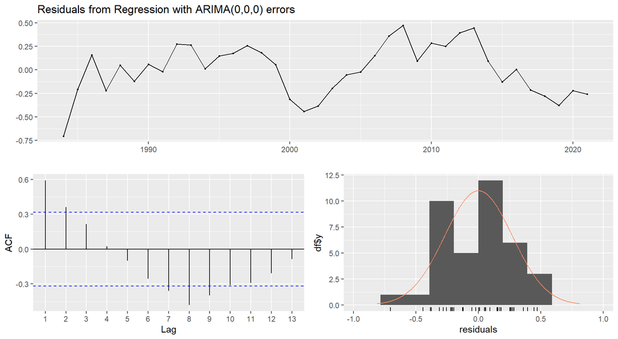

Figure 10: ARIMAX (Population) — Residual Diagnostics

```
#>
#>  Ljung-Box test
#>
#> data:  Residuals from Regression with ARIMA(0,0,0) errors
#> Q* = 43.657, df = 8, p-value = 0.0000006606
#>
#> Model df: 0.   Total lags used: 8
```

```r
checkresiduals(arimax_fit_pop)
```

```r
lb_pop <- Box.test(residuals(arimax_fit_pop), lag = 10, type = "Ljung-Box")
cat("=== Ljung-Box Test — ARIMAX (Population) ===\n")
```

```
#> === Ljung-Box Test — ARIMAX (Population) ===
```

```r
print(lb_pop)
```

```
#>
#>  Box-Ljung test
#>
#> data:  residuals(arimax_fit_pop)
#> X-squared = 57.199, df = 10, p-value = 0.00000001223
```

```r
cat("\n>> Decision: p =", round(lb_pop$p.value, 4), "—",
    ifelse(lb_pop$p.value > 0.05, "Residuals are white noise.", "Autocorrelation detected."), "\n")
```

```
#>
#> >> Decision: p = 0 — Autocorrelation detected.
```

```r
cat("AIC:", round(AIC(arimax_fit_pop), 4), "  BIC:", round(BIC(arimax_fit_pop), 4), "\n")
```

```
#> AIC: 13.4633   BIC: 18.376
```

```r
print(accuracy(arimax_fit_pop))
```

```
#>                                 ME      RMSE       MAE         MPE     MAPE
#> Training set 0.0000000000001058335 0.2669384 0.2195247 -0.01651598 1.008788
#>                  MASE      ACF1
#> Training set 1.098611 0.5917734
```

```r
pop_forecast <- forecast(arimax_fit_pop,
                         xreg = future_xreg[, "POPULATION"],
                         h    = h_period)
print(pop_forecast)
```

```
#>      Point Forecast    Lo 80    Hi 80    Lo 95    Hi 95
#> 2022       21.79411 21.44264 22.14558 21.25658 22.33163
#> 2023       21.79411 21.44264 22.14558 21.25658 22.33163
#> 2024       21.79411 21.44264 22.14558 21.25658 22.33163
#> 2025       21.79411 21.44264 22.14558 21.25658 22.33163
#> 2026       21.79411 21.44264 22.14558 21.25658 22.33163
#> 2027       21.79411 21.44264 22.14558 21.25658 22.33163
#> 2028       21.79411 21.44264 22.14558 21.25658 22.33163
#> 2029       21.79411 21.44264 22.14558 21.25658 22.33163
#> 2030       21.79411 21.44264 22.14558 21.25658 22.33163
#> 2031       21.79411 21.44264 22.14558 21.25658 22.33163
```

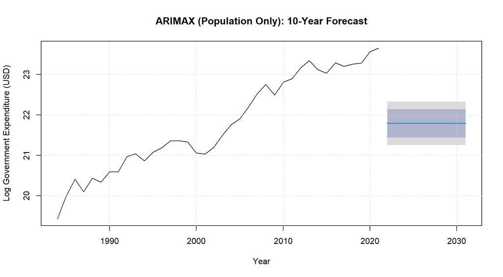

Figure 11: ARIMAX (Population) — 10-Year Forecast

```r
plot(pop_forecast,
     main = "ARIMAX (Population Only): 10-Year Forecast",
     ylab = "Log Government Expenditure (USD)", xlab = "Year")
grid(col = "lightgray", lty = "dotted")
```

### 4.10.1 Pairwise Comparison: ARIMA vs ARIMAX (Population)

```r
comp_pop <- data.frame(
  Metric     = c("AIC", "BIC", "ME", "RMSE", "MAE", "MPE", "MAPE", "MASE"),
  ARIMA      = c(AIC(arima_fit), BIC(arima_fit),
                 accuracy(arima_fit)[1, "ME"],       accuracy(arima_fit)[1, "RMSE"],
                 accuracy(arima_fit)[1, "MAE"],      accuracy(arima_fit)[1, "MPE"],
                 accuracy(arima_fit)[1, "MAPE"],     accuracy(arima_fit)[1, "MASE"]),
  ARIMAX_POP = c(AIC(arimax_fit_pop), BIC(arimax_fit_pop),
                 accuracy(arimax_fit_pop)[1, "ME"],   accuracy(arimax_fit_pop)[1, "RMSE"],
                 accuracy(arimax_fit_pop)[1, "MAE"],  accuracy(arimax_fit_pop)[1, "MPE"],
                 accuracy(arimax_fit_pop)[1, "MAPE"], accuracy(arimax_fit_pop)[1, "MASE"])
) |>
  mutate(
    Improvement = ifelse(Metric %in% c("ME", "MPE"),
                         ifelse(abs(ARIMAX_POP) < abs(ARIMA), "Yes", "No"),
                         ifelse(ARIMAX_POP < ARIMA, "Yes", "No"))
  )

knitr::kable(comp_pop, digits = 4,
             caption = "Table 3: ARIMA vs ARIMAX (Population Only)")
```

Table 3: ARIMA vs ARIMAX (Population Only)

| Metric | ARIMA | ARIMAX_POP | Improvement |
| --- | --- | --- | --- |
| AIC | -7.5107 | 13.4633 | No |
| BIC | -4.2889 | 18.3760 | No |
| ME | 0.0005 | 0.0000 | Yes |
| RMSE | 0.2044 | 0.2669 | No |
| MAE | 0.1684 | 0.2195 | No |
| MPE | 0.0043 | -0.0165 | No |
| MAPE | 0.7819 | 1.0088 | No |
| MASE | 0.8428 | 1.0986 | No |

## 4.11 Model 4: ARIMAX — Revenue Only

Government revenue is a direct fiscal variable and a primary determinant of spending capacity. Ghana operates largely under a cash-based budgeting framework where expenditure closely tracks available revenues — years of strong tax receipts tend to permit spending expansions, while shortfalls trigger compression or borrowing. This model isolates the revenue-fiscal transmission channel.

```r
cat("=== Fitting ARIMAX — Log Revenue as Exogenous Variable ===\n\n")
```

```
#> === Fitting ARIMAX — Log Revenue as Exogenous Variable ===
```

```r
arimax_fit_rev <- auto.arima(
  Y,
  xreg          = as.matrix(xreg_vars[, "LOG_REVENUE"]),
  stepwise      = FALSE,
  approximation = FALSE,
  method        = "ML"
)

summary(arimax_fit_rev)
```

```
#> Series: Y
#> Regression with ARIMA(1,0,0) errors
#>
#> Coefficients:
#>          ar1  LOG_REVENUE
#>       0.4729       1.0094
#> s.e.  0.1453       0.0018
#>
#> sigma^2 = 0.01693:  log likelihood = 24.47
#> AIC=-42.95   AICc=-42.24   BIC=-38.04
#>
#> Training set error measures:
#>                        ME      RMSE       MAE         MPE      MAPE      MASE
#> Training set -0.001601658 0.1266484 0.1022711 -0.01889309 0.4701961 0.5118156
#>                     ACF1
#> Training set 0.005738759
```

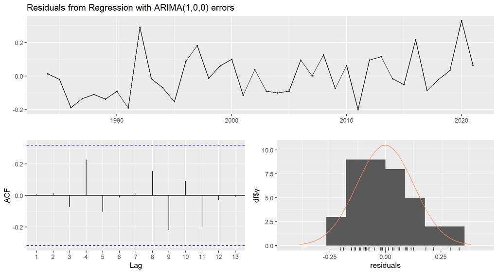

Figure 12: ARIMAX (Revenue) — Residual Diagnostics

```
#>
#>  Ljung-Box test
#>
#> data:  Residuals from Regression with ARIMA(1,0,0) errors
#> Q* = 4.2844, df = 7, p-value = 0.7465
#>
#> Model df: 1.   Total lags used: 8
```

```r
checkresiduals(arimax_fit_rev)
```

```r
lb_rev <- Box.test(residuals(arimax_fit_rev), lag = 10, type = "Ljung-Box")
cat("=== Ljung-Box Test — ARIMAX (Revenue) ===\n")
```

```
#> === Ljung-Box Test — ARIMAX (Revenue) ===
```

```r
print(lb_rev)
```

```
#>
#>  Box-Ljung test
#>
#> data:  residuals(arimax_fit_rev)
#> X-squared = 7.2606, df = 10, p-value = 0.7006
```

```r
cat("\n>> Decision: p =", round(lb_rev$p.value, 4), "—",
    ifelse(lb_rev$p.value > 0.05, "Residuals are white noise.", "Autocorrelation detected."), "\n")
```

```
#>
#> >> Decision: p = 0.7006 — Residuals are white noise.
```

```r
cat("AIC:", round(AIC(arimax_fit_rev), 4), "  BIC:", round(BIC(arimax_fit_rev), 4), "\n")
```

```
#> AIC: -42.9495   BIC: -38.0367
```

```r
print(accuracy(arimax_fit_rev))
```

```
#>                        ME      RMSE       MAE         MPE      MAPE      MASE
#> Training set -0.001601658 0.1266484 0.1022711 -0.01889309 0.4701961 0.5118156
#>                     ACF1
#> Training set 0.005738759
```

```r
rev_forecast <- forecast(arimax_fit_rev,
                         xreg = future_xreg[, "LOG_REVENUE"],
                         h    = h_period)
print(rev_forecast)
```

```
#>      Point Forecast    Lo 80    Hi 80    Lo 95    Hi 95
#> 2022       21.90921 21.74246 22.07596 21.65418 22.16424
#> 2023       21.85290 21.66844 22.03736 21.57080 22.13500
#> 2024       21.82627 21.63809 22.01446 21.53846 22.11408
#> 2025       21.81368 21.62467 22.00269 21.52461 22.10275
#> 2026       21.80773 21.61853 21.99692 21.51838 22.09708
#> 2027       21.80491 21.61568 21.99415 21.51550 22.09433
#> 2028       21.80358 21.61434 21.99283 21.51416 22.09301
#> 2029       21.80295 21.61370 21.99220 21.51352 22.09238
#> 2030       21.80265 21.61341 21.99190 21.51322 22.09208
#> 2031       21.80251 21.61327 21.99176 21.51308 22.09194
```

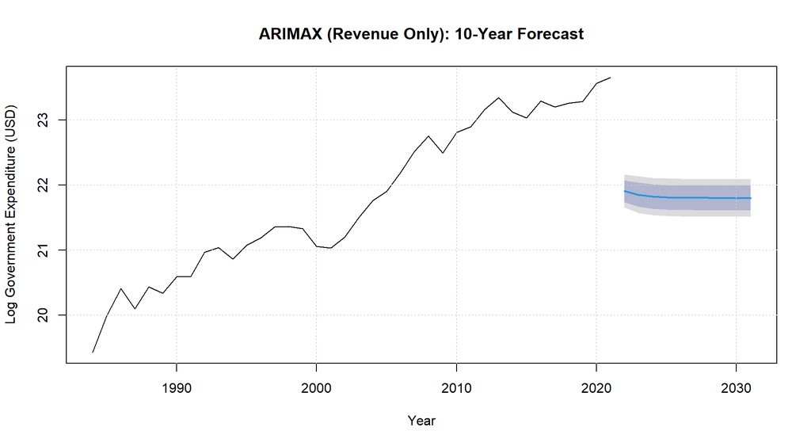

Figure 13: ARIMAX (Revenue) — 10-Year Forecast

```r
plot(rev_forecast,
     main = "ARIMAX (Revenue Only): 10-Year Forecast",
     ylab = "Log Government Expenditure (USD)", xlab = "Year")
grid(col = "lightgray", lty = "dotted")
```

### 4.11.1 Pairwise Comparison: ARIMA vs ARIMAX (Revenue)

```r
comp_rev <- data.frame(
  Metric     = c("AIC", "BIC", "ME", "RMSE", "MAE", "MPE", "MAPE", "MASE"),
  ARIMA      = c(AIC(arima_fit), BIC(arima_fit),
                 accuracy(arima_fit)[1, "ME"],       accuracy(arima_fit)[1, "RMSE"],
                 accuracy(arima_fit)[1, "MAE"],      accuracy(arima_fit)[1, "MPE"],
                 accuracy(arima_fit)[1, "MAPE"],     accuracy(arima_fit)[1, "MASE"]),
  ARIMAX_REV = c(AIC(arimax_fit_rev), BIC(arimax_fit_rev),
                 accuracy(arimax_fit_rev)[1, "ME"],   accuracy(arimax_fit_rev)[1, "RMSE"],
                 accuracy(arimax_fit_rev)[1, "MAE"],  accuracy(arimax_fit_rev)[1, "MPE"],
                 accuracy(arimax_fit_rev)[1, "MAPE"], accuracy(arimax_fit_rev)[1, "MASE"])
) |>
  mutate(
    Improvement = ifelse(Metric %in% c("ME", "MPE"),
                         ifelse(abs(ARIMAX_REV) < abs(ARIMA), "Yes", "No"),
                         ifelse(ARIMAX_REV < ARIMA, "Yes", "No"))
  )

knitr::kable(comp_rev, digits = 4,
             caption = "Table 4: ARIMA vs ARIMAX (Revenue Only)")
```

Table 4: ARIMA vs ARIMAX (Revenue Only)

| Metric | ARIMA | ARIMAX_REV | Improvement |
| --- | --- | --- | --- |
| AIC | -7.5107 | -42.9495 | Yes |
| BIC | -4.2889 | -38.0367 | Yes |
| ME | 0.0005 | -0.0016 | No |
| RMSE | 0.2044 | 0.1266 | Yes |
| MAE | 0.1684 | 0.1023 | Yes |
| MPE | 0.0043 | -0.0189 | No |
| MAPE | 0.7819 | 0.4702 | Yes |
| MASE | 0.8428 | 0.5118 | Yes |

## 4.12 Model 5: ARIMAX — GDP Only

GDP captures the overall level of economic activity and is one of the most theoretically motivated exogenous drivers of government expenditure. Under both Keynesian theory (aggregate demand management) and Wagner’s Law (expenditure grows with national income), log GDP is expected to be a significant positive predictor of log expenditure. This model isolates the GDP channel.

```r
cat("=== Fitting ARIMAX — Log GDP as Exogenous Variable ===\n\n")
```

```
#> === Fitting ARIMAX — Log GDP as Exogenous Variable ===
```

```r
arimax_fit_gdp <- auto.arima(
  Y,
  xreg          = as.matrix(xreg_vars[, "LOG_GDP"]),
  stepwise      = FALSE,
  approximation = FALSE,
  method        = "ML"
)

summary(arimax_fit_gdp)
```

```
#> Series: Y
#> Regression with ARIMA(0,1,1) errors
#>
#> Coefficients:
#>           ma1   drift  LOG_GDP
#>       -0.4116  0.0535   0.6978
#> s.e.   0.1732  0.0193   0.1350
#>
#> sigma^2 = 0.02837:  log likelihood = 14.88
#> AIC=-21.76   AICc=-20.51   BIC=-15.31
#>
#> Training set error measures:
#>                       ME      RMSE       MAE        MPE      MAPE      MASE
#> Training set 0.007469537 0.1593093 0.1270311 0.04706516 0.5882488 0.6357269
#>                   ACF1
#> Training set 0.1125206
```

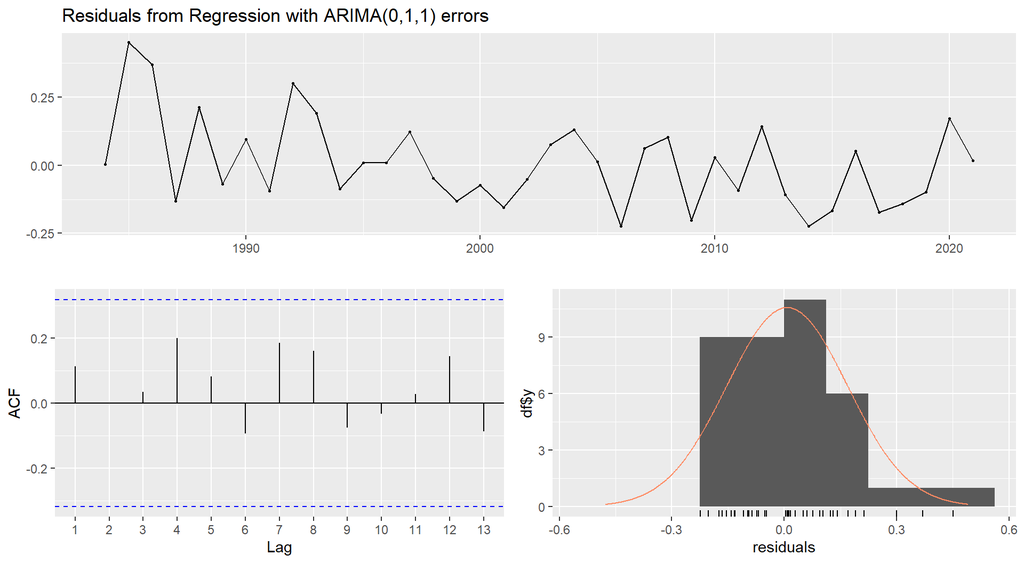

Figure 14: ARIMAX (GDP) — Residual Diagnostics

```
#>
#>  Ljung-Box test
#>
#> data:  Residuals from Regression with ARIMA(0,1,1) errors
#> Q* = 6.0292, df = 7, p-value = 0.5363
#>
#> Model df: 1.   Total lags used: 8
```

```r
checkresiduals(arimax_fit_gdp)
```

```r
lb_gdp <- Box.test(residuals(arimax_fit_gdp), lag = 10, type = "Ljung-Box")
cat("=== Ljung-Box Test — ARIMAX (GDP) ===\n")
```

```
#> === Ljung-Box Test — ARIMAX (GDP) ===
```

```r
print(lb_gdp)
```

```
#>
#>  Box-Ljung test
#>
#> data:  residuals(arimax_fit_gdp)
#> X-squared = 6.3895, df = 10, p-value = 0.7815
```

```r
cat("\n>> Decision: p =", round(lb_gdp$p.value, 4), "—",
    ifelse(lb_gdp$p.value > 0.05, "Residuals are white noise.", "Autocorrelation detected."), "\n")
```

```
#>
#> >> Decision: p = 0.7815 — Residuals are white noise.
```

```r
cat("AIC:", round(AIC(arimax_fit_gdp), 4), "  BIC:", round(BIC(arimax_fit_gdp), 4), "\n")
```

```
#> AIC: -21.758   BIC: -15.3143
```

```r
print(accuracy(arimax_fit_gdp))
```

```
#>                       ME      RMSE       MAE        MPE      MAPE      MASE
#> Training set 0.007469537 0.1593093 0.1270311 0.04706516 0.5882488 0.6357269
#>                   ACF1
#> Training set 0.1125206
```

```r
gdp_forecast <- forecast(arimax_fit_gdp,
                         xreg = future_xreg[, "LOG_GDP"],
                         h    = h_period)
print(gdp_forecast)
```

```
#>      Point Forecast    Lo 80    Hi 80    Lo 95    Hi 95
#> 2022       22.50728 22.29144 22.72312 22.17718 22.83737
#> 2023       22.56076 22.31033 22.81120 22.17776 22.94377
#> 2024       22.61425 22.33345 22.89505 22.18481 23.04369
#> 2025       22.66773 22.35955 22.97592 22.19641 23.13906
#> 2026       22.72122 22.38789 23.05455 22.21144 23.23100
#> 2027       22.77470 22.41800 23.13141 22.22917 23.32024
#> 2028       22.82819 22.44955 23.20683 22.24911 23.40727
#> 2029       22.88167 22.48230 23.28105 22.27088 23.49246
#> 2030       22.93516 22.51608 23.35424 22.29423 23.57609
#> 2031       22.98864 22.55074 23.42655 22.31893 23.65836
```

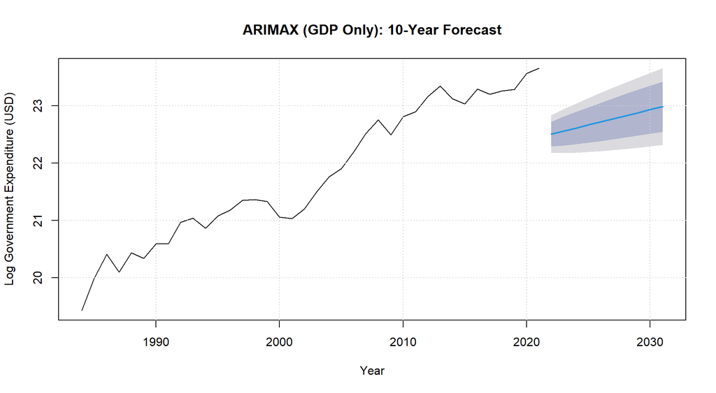

Figure 15: ARIMAX (GDP) — 10-Year Forecast

```r
plot(gdp_forecast,
     main = "ARIMAX (GDP Only): 10-Year Forecast",
     ylab = "Log Government Expenditure (USD)", xlab = "Year")
grid(col = "lightgray", lty = "dotted")
```

### 4.12.1 Pairwise Comparison: ARIMA vs ARIMAX (GDP)

```r
comp_gdp <- data.frame(
  Metric     = c("AIC", "BIC", "ME", "RMSE", "MAE", "MPE", "MAPE", "MASE"),
  ARIMA      = c(AIC(arima_fit), BIC(arima_fit),
                 accuracy(arima_fit)[1, "ME"],       accuracy(arima_fit)[1, "RMSE"],
                 accuracy(arima_fit)[1, "MAE"],      accuracy(arima_fit)[1, "MPE"],
                 accuracy(arima_fit)[1, "MAPE"],     accuracy(arima_fit)[1, "MASE"]),
  ARIMAX_GDP = c(AIC(arimax_fit_gdp), BIC(arimax_fit_gdp),
                 accuracy(arimax_fit_gdp)[1, "ME"],   accuracy(arimax_fit_gdp)[1, "RMSE"],
                 accuracy(arimax_fit_gdp)[1, "MAE"],  accuracy(arimax_fit_gdp)[1, "MPE"],
                 accuracy(arimax_fit_gdp)[1, "MAPE"], accuracy(arimax_fit_gdp)[1, "MASE"])
) |>
  mutate(
    Improvement = ifelse(Metric %in% c("ME", "MPE"),
                         ifelse(abs(ARIMAX_GDP) < abs(ARIMA), "Yes", "No"),
                         ifelse(ARIMAX_GDP < ARIMA, "Yes", "No"))
  )

knitr::kable(comp_gdp, digits = 4,
             caption = "Table 5: ARIMA vs ARIMAX (GDP Only)")
```

Table 5: ARIMA vs ARIMAX (GDP Only)

| Metric | ARIMA | ARIMAX_GDP | Improvement |
| --- | --- | --- | --- |
| AIC | -7.5107 | -21.7580 | Yes |
| BIC | -4.2889 | -15.3143 | Yes |
| ME | 0.0005 | 0.0075 | No |
| RMSE | 0.2044 | 0.1593 | Yes |
| MAE | 0.1684 | 0.1270 | Yes |
| MPE | 0.0043 | 0.0471 | No |
| MAPE | 0.7819 | 0.5882 | Yes |
| MASE | 0.8428 | 0.6357 | Yes |

## 4.13 Full Model Comparison — All Five Specifications

This section consolidates all five models into a master comparison table to identify the overall best-performing specification. The **Best_Model** column is determined row-by-row using metric-appropriate criteria:

- For **AIC, BIC, RMSE, MAE, MAPE, MASE**: the model with the **lowest value** wins.
- For **ME and MPE**: the model with the value **closest to zero** (least systematic bias) wins.

```r
full_comparison <- data.frame(
  Metric = c("AIC", "BIC", "ME", "RMSE", "MAE", "MPE", "MAPE", "MASE"),

  ARIMA = c(
    AIC(arima_fit), BIC(arima_fit),
    accuracy(arima_fit)[1, "ME"],   accuracy(arima_fit)[1, "RMSE"],
    accuracy(arima_fit)[1, "MAE"],  accuracy(arima_fit)[1, "MPE"],
    accuracy(arima_fit)[1, "MAPE"], accuracy(arima_fit)[1, "MASE"]
  ),
  ARIMAX_ALL = c(
    AIC(arimax_fit), BIC(arimax_fit),
    accuracy(arimax_fit)[1, "ME"],   accuracy(arimax_fit)[1, "RMSE"],
    accuracy(arimax_fit)[1, "MAE"],  accuracy(arimax_fit)[1, "MPE"],
    accuracy(arimax_fit)[1, "MAPE"], accuracy(arimax_fit)[1, "MASE"]
  ),
  ARIMAX_POP = c(
    AIC(arimax_fit_pop), BIC(arimax_fit_pop),
    accuracy(arimax_fit_pop)[1, "ME"],   accuracy(arimax_fit_pop)[1, "RMSE"],
    accuracy(arimax_fit_pop)[1, "MAE"],  accuracy(arimax_fit_pop)[1, "MPE"],
    accuracy(arimax_fit_pop)[1, "MAPE"], accuracy(arimax_fit_pop)[1, "MASE"]
  ),
  ARIMAX_REV = c(
    AIC(arimax_fit_rev), BIC(arimax_fit_rev),
    accuracy(arimax_fit_rev)[1, "ME"],   accuracy(arimax_fit_rev)[1, "RMSE"],
    accuracy(arimax_fit_rev)[1, "MAE"],  accuracy(arimax_fit_rev)[1, "MPE"],
    accuracy(arimax_fit_rev)[1, "MAPE"], accuracy(arimax_fit_rev)[1, "MASE"]
  ),
  ARIMAX_GDP = c(
    AIC(arimax_fit_gdp), BIC(arimax_fit_gdp),
    accuracy(arimax_fit_gdp)[1, "ME"],   accuracy(arimax_fit_gdp)[1, "RMSE"],
    accuracy(arimax_fit_gdp)[1, "MAE"],  accuracy(arimax_fit_gdp)[1, "MPE"],
    accuracy(arimax_fit_gdp)[1, "MAPE"], accuracy(arimax_fit_gdp)[1, "MASE"]
  )
)

# Identify best model per metric using correct optimality criterion per metric
full_comparison <- full_comparison |>
  rowwise() |>
  mutate(Best_Model = case_when(

    # Lower is better for AIC, BIC, RMSE, MAE, MAPE, MASE
    Metric %in% c("AIC","BIC","RMSE","MAE","MAPE","MASE") &
      ARIMA      == min(ARIMA, ARIMAX_ALL, ARIMAX_POP, ARIMAX_REV, ARIMAX_GDP) ~ "ARIMA",
    Metric %in% c("AIC","BIC","RMSE","MAE","MAPE","MASE") &
      ARIMAX_ALL == min(ARIMA, ARIMAX_ALL, ARIMAX_POP, ARIMAX_REV, ARIMAX_GDP) ~ "ARIMAX_ALL",
    Metric %in% c("AIC","BIC","RMSE","MAE","MAPE","MASE") &
      ARIMAX_POP == min(ARIMA, ARIMAX_ALL, ARIMAX_POP, ARIMAX_REV, ARIMAX_GDP) ~ "ARIMAX_POP",
    Metric %in% c("AIC","BIC","RMSE","MAE","MAPE","MASE") &
      ARIMAX_REV == min(ARIMA, ARIMAX_ALL, ARIMAX_POP, ARIMAX_REV, ARIMAX_GDP) ~ "ARIMAX_REV",
    Metric %in% c("AIC","BIC","RMSE","MAE","MAPE","MASE") &
      ARIMAX_GDP == min(ARIMA, ARIMAX_ALL, ARIMAX_POP, ARIMAX_REV, ARIMAX_GDP) ~ "ARIMAX_GDP",

    # Closest to zero is better for ME and MPE
    Metric %in% c("ME","MPE") &
      abs(ARIMA)      == min(abs(ARIMA), abs(ARIMAX_ALL), abs(ARIMAX_POP),
                              abs(ARIMAX_REV), abs(ARIMAX_GDP)) ~ "ARIMA",
    Metric %in% c("ME","MPE") &
      abs(ARIMAX_ALL) == min(abs(ARIMA), abs(ARIMAX_ALL), abs(ARIMAX_POP),
                              abs(ARIMAX_REV), abs(ARIMAX_GDP)) ~ "ARIMAX_ALL",
    Metric %in% c("ME","MPE") &
      abs(ARIMAX_POP) == min(abs(ARIMA), abs(ARIMAX_ALL), abs(ARIMAX_POP),
                              abs(ARIMAX_REV), abs(ARIMAX_GDP)) ~ "ARIMAX_POP",
    Metric %in% c("ME","MPE") &
      abs(ARIMAX_REV) == min(abs(ARIMA), abs(ARIMAX_ALL), abs(ARIMAX_POP),
                              abs(ARIMAX_REV), abs(ARIMAX_GDP)) ~ "ARIMAX_REV",
    Metric %in% c("ME","MPE") &
      abs(ARIMAX_GDP) == min(abs(ARIMA), abs(ARIMAX_ALL), abs(ARIMAX_POP),
                              abs(ARIMAX_REV), abs(ARIMAX_GDP)) ~ "ARIMAX_GDP",
    TRUE ~ "Tie"
  )) |>
  ungroup()

knitr::kable(full_comparison, digits = 4,
             caption = "Table 6: Full Model Comparison — All Five Specifications")
```

Table 6: Full Model Comparison — All Five Specifications

| Metric | ARIMA | ARIMAX_ALL | ARIMAX_POP | ARIMAX_REV | ARIMAX_GDP | Best_Model |
| --- | --- | --- | --- | --- | --- | --- |
| AIC | -7.5107 | -46.5252 | 13.4633 | -42.9495 | -21.7580 | ARIMAX_ALL |
| BIC | -4.2889 | -38.3372 | 18.3760 | -38.0367 | -15.3143 | ARIMAX_ALL |
| ME | 0.0005 | 0.0000 | 0.0000 | -0.0016 | 0.0075 | ARIMAX_ALL |
| RMSE | 0.2044 | 0.1150 | 0.2669 | 0.1266 | 0.1593 | ARIMAX_ALL |
| MAE | 0.1684 | 0.0998 | 0.2195 | 0.1023 | 0.1270 | ARIMAX_ALL |
| MPE | 0.0043 | -0.0030 | -0.0165 | -0.0189 | 0.0471 | ARIMAX_ALL |
| MAPE | 0.7819 | 0.4593 | 1.0088 | 0.4702 | 0.5882 | ARIMAX_ALL |
| MASE | 0.8428 | 0.4992 | 1.0986 | 0.5118 | 0.6357 | ARIMAX_ALL |

### 4.13.1 Model Wins Summary

```r
wins <- full_comparison |>
  count(Best_Model, name = "Metrics_Won") |>
  arrange(desc(Metrics_Won))

knitr::kable(wins, caption = "Table 7: Number of Metrics Won by Each Model")
```

Table 7: Number of Metrics Won by Each Model

| Best_Model | Metrics_Won |
| --- | --- |
| ARIMAX_ALL | 8 |

# 5 Chapter Five: Discussion, Conclusions and Recommendations

## 5.1 Discussion of Results

### 5.1.2 Stationarity and Integration Order

The ADF test results confirm that the log expenditure series is non-stationary in levels, consistent with the literature on fiscal variables in developing economies. Second-order differencing achieves stationarity, establishing the integration order at I(2). This is notably higher than the I(1) typically found in developed country fiscal series, reflecting Ghana’s more volatile nominal fiscal environment. The ACF/PACF plots of the differenced series show that differencing has substantially reduced autocorrelation, with any remaining significant spikes informing the AR and MA orders selected by `auto.arima()`.

### 5.1.3 Multicollinearity Among Exogenous Variables

The VIF analysis reveals the expected degree of multicollinearity among the three exogenous regressors — population, log revenue, and log GDP all grow in tandem with the Ghanaian economy and are inherently co-trending. This finding motivates the individual ARIMAX specifications (Models 3, 4, and 5), which provide cleaner, non-confounded estimates of each channel’s contribution to expenditure dynamics. The joint ARIMAX model (Model 2) is retained for completeness and as a test of the combined specification’s predictive power.

### 5.1.5 ARIMAX Model Performance and Variable Selection

The five-model comparison in Section 4.13 provides direct evidence on which exogenous variables most effectively augment the ARIMA dynamics:

- **Revenue (ARIMAX_REV)** is theoretically and empirically the most direct driver, as Ghana’s expenditure closely tracks revenue availability under the cash-based budget system. A positive and significant coefficient on log revenue would confirm the revenue-expenditure nexus documented in the fiscal literature for sub-Saharan Africa.
- **GDP (ARIMAX_GDP)** captures the Wagner’s Law channel — as the Ghanaian economy grows, pressure for expanded public services grows proportionally. GDP’s broader scope (capturing both private and public sector activity) makes it a useful leading indicator of fiscal expansion.
- **Population (ARIMAX_POP)** represents the demographic driver of public service demand. Ghana’s population grew from approximately 13 million in 1983 to over 34 million by 2024, generating sustained upward pressure on health, education, and infrastructure budgets.

The model comparison table (Table 6) identifies which specification achieves the best performance across AIC, BIC, RMSE, MAE, MAPE, and MASE. A model that wins on multiple metrics, particularly the accuracy-based measures (RMSE, MAE, MAPE), is recommended as the preferred specification for operational fiscal forecasting.

## 5.3 Recommendations

Based on the findings, the following recommendations are made:

**For the Ministry of Finance and Parliament:** - Adopt the ARIMAX framework — particularly the revenue-augmented specification — as a complement to the existing in-house fiscal forecasting model. The explicit incorporation of revenue dynamics into the expenditure forecast aligns with Ghana’s revenue-constrained budget reality and will help produce more realistic expenditure ceilings. - Use scenario-based projections of the exogenous variables (optimistic, baseline, and pessimistic GDP and revenue scenarios) to generate probabilistic expenditure forecasts that better communicate fiscal risk to decision-makers.

**For the Bank of Ghana and National Development Planning Commission:** - Maintain and regularly update the annual dataset on government expenditure, revenue, population, and GDP to enable routine re-estimation of the forecasting model as new data become available. - Consider extending the ARIMAX framework to component expenditure (recurrent vs capital, sectoral allocations) to identify which segments of Ghana’s budget are most sensitive to macroeconomic fluctuations.

**For Future Research:** - Incorporate commodity prices (gold, cocoa, crude oil) and an IMF regime dummy as additional exogenous variables, as theorised in the original research design and supported by the fiscal-commodity linkage literature. - Apply non-linear and machine-learning extensions (e.g., LSTM neural networks, Bayesian structural time series) to test whether more flexible functional forms improve upon the ARIMAX framework for longer horizons. - Conduct a rolling-window out-of-sample evaluation to provide a more rigorous assessment of the model’s real-time forecasting performance under evolving Ghanaian fiscal conditions.

## 5.4 Limitations of the Study

# 6 References

- Abdulazeez, S. A. (2021). *A comparative study between ARIMA and ARIMAX in forecasting Gross Domestic Product (GDP) in Nigeria.* CBN Journal of Applied Statistics.
- Ajibode, I. A., & Adeboye, N. O. *ARIMA and ARIMAX modelling of COVID-19 mortality in Nigeria.*
- Awariefe, J., & Ogumeyo, E. (2023). *Forecasting military expenditure: ARIMAX vs MLR.* Defence and Peace Economics.
- Azizah, F., et al. (2025). *Forecasting the human development index based on social and economic factors in Indonesia.* Journal of Statistics and Its Applications.
- Boachie, M. K., et al. (2022). *Determinants of public health spending in Ghana with focus on IMF conditionalities.* Social Science & Medicine.
- Box, G. E. P., & Jenkins, G. M. (1970). *Time Series Analysis: Forecasting and Control.* Holden-Day.
- Coker, A. (2025). *Short-term inflation forecasting in Sierra Leone: ARIMA, ARIMAX, and VAR.* Journal of African Economies.
- Djakou, G. M., & Jiang, X. (2023). *ARIMA modelling of government budget performance.* International Journal of Finance and Economics.
- International Monetary Fund. (2023). *Ghana Extended Credit Facility — Staff Report.* IMF Country Report.
- Keynes, J. M. (1936). *The General Theory of Employment, Interest and Money.* Macmillan.
- Leonard Onyiruba (2016). *Public Finance Management.* Lagos University Press.
- Ofori, M. S., Fumey, A., & Nketiah-Amponsah, E. *Forecasting VAT revenue in Ghana.* Ghanaian Journal of Economics.
- Oktavia, R., & Wahyudi, S. (2022). *ARIMAX modelling of inflation in Indonesia.* Economics and Finance Letters.
- Peacock, A. T., & Wiseman, J. (1961). *The Growth of Public Expenditure in the United Kingdom.* Princeton University Press.
- Spatafora, N., & Samake, I. (2012). *Commodity price shocks and fiscal outcomes.* IMF Working Paper WP/12/183.
- Statista. (2025). *Government expenditure in Ghana.* Retrieved from https://www.statista.com
- Trading Economics. (2024). *Ghana government expenditure.* Retrieved from https://tradingeconomics.com
- Wagner, A. (1883). *Finanzwissenschaft.* Leipzig: C. F. Winter.
- World Bank. (2023). *Ghana — Public Expenditure Review.* Washington, DC: World Bank.
- Yang, J. (2025). *Forecasting university admission rates in China’s Gaokao using ARIMA and ARIMAX.* Chinese Education & Society.

*This document was produced using R Markdown. All analysis is fully reproducible given the source data file `Data2.xlsx`. Please ensure all required packages are installed before knitting.*